# Predicting Car Sales

### 3. Simple Support Vector Machine (with linear kernel)

```python
from sklearn.svm import LinearSVC
model = LinearSVC(dual=False, class_weight='balanced', random_state=42)
search_space = {'C': [0.01, 0.1, 1, 10, 100]}

model_grid_svc = GridSearchCV(estimator=model,
                         param_grid=search_space,
                         cv=5,
                         n_jobs=-1,
                         scoring='f1')

model_grid_svc.fit(features_train, target_train)
print(model_grid_svc.best_estimator_, model_grid_svc.best_score_)
```

```
LinearSVC(C=0.01, class_weight='balanced', dual=False, random_state=42) 0.3676106510997626
```

```python
# predict and evaluate on train set
result_svc_lk_train = model_grid_svc.predict(features_train)

print('===TrainData===')
print('precision: ', precision_score(target_train, result_svc_lk_train))
print('recall: ', recall_score(target_train, result_svc_lk_train))
print('f1: ', f1_score(target_train, result_svc_lk_train))

# predict and evaluate on test set
result_svc_lk_test = model_grid_svc.predict(features_test)

print('===TestData===')
print('precision: ', precision_score(target_test, result_svc_lk_test))
print('recall: ', recall_score(target_test, result_svc_lk_test))
print('f1: ', f1_score(target_test, result_svc_lk_test))
```

```
===TrainData===
precision:  0.27138242894056847
recall:  0.5788095894185726
f1:  0.36951358958571556
===TestData===
precision:  0.2815028901734104
recall:  0.5756501182033097
f1:  0.3781055900621118
```

```python
# f1 score slightly imporved compared to logistic regressions
```

### 4. Support Vector Machine with Gaussian kernel (rbf)

```python
# Attention: the training takes long (35min)

from sklearn.svm import SVC
model_rbf = SVC(kernel='rbf', gamma='scale', class_weight='balanced', random_state=42)
search_space = {'C': [1, 10]} # Remember: high C = hard margin, low C = soft margin

model_grid2 = GridSearchCV(estimator=model_rbf,
                         param_grid=search_space,
                         cv=5,
                         n_jobs=-1,
                         scoring='f1')

model_grid2.fit(features_train, target_train)
print(model_grid2.best_estimator_, model_grid2.best_score_)
```

```
SVC(C=1, class_weight='balanced', random_state=42) 0.37395536383668904
```

```python
# saving the model
import joblib
joblib.dump(model_grid2.best_estimator_, 'best_model.pkl')

## for loading the model later

#best_model_loaded = joblib.load('best_model.pkl')
#print(best_model_loaded.get_params())
```

```
['best_model.pkl']
```

```python
# predict and evaluate on train set
result_svc_rbf_train = model_grid2.predict(features_train)

print('===TrainData===')
print('precision: ', precision_score(target_train, result_svc_rbf_train))
print('recall: ', recall_score(target_train, result_svc_rbf_train))
print('f1: ', f1_score(target_train, result_svc_rbf_train))

# predict and evaluate on test set
result_svc_rbf_test = model_grid2.predict(features_test)

print('===TestData===')
print('precision: ', precision_score(target_test, result_svc_rbf_test))
print('recall: ', recall_score(target_test, result_svc_rbf_test))
print('f1: ', f1_score(target_test, result_svc_rbf_test))
```

```
===TrainData===
precision:  0.3028823956203417
recall:  0.6326811793882612
f1:  0.4096525268745261
===TestData===
precision:  0.28072289156626506
recall:  0.5508274231678487
f1:  0.37190742218675177
```

```python
# The results for the train data look good as f1 improved to 0.41, however the test data show no significant improvement.
# Therefor we here have a typical case of overfitting (model learned the train data too good and cannot similarly well predict new data).
```

### 5. Random Forest with Bayesian Optimization

```python
from sklearn.ensemble import RandomForestClassifier
import optuna
from optuna.samplers import TPESampler
from sklearn.model_selection import cross_val_score
import matplotlib.pyplot as plt
from sklearn.model_selection import learning_curve
import time
# importing plotly and enable jupyter notebooks for showing optuna visualisations
import plotly.io as pio
pio.renderers.default = 'iframe'
```

```python
# Random Forest with Bayesian Optimization
def objective(trial):
    """return maximized f1-score"""

    # search space
    n_estimators = trial.suggest_int('n_estimators', 50, 250)
    max_depth = trial.suggest_int('max_depth', 3, 15)
    max_features = trial.suggest_categorical('max_features', choices = ['log2', 'sqrt'])
    min_samples_split = trial.suggest_int(name="min_samples_split", low=2, high=10, step=2)
    min_samples_leaf = trial.suggest_int(name="min_samples_leaf", low=1, high=4, step=1)

    params = {'n_estimators': n_estimators, # no. of trees
             'max_features': max_features, # number of features to consider when looking for the best split
             'max_depth': max_depth, # no. of splits in trees
             'min_samples_split': min_samples_split, # minimum number of samples required to split an internal node
             'min_samples_leaf': min_samples_leaf} # minimale Größe der Blätter (anzahl Datenpunkte)

    # random forest classifier object
    model_rf = RandomForestClassifier(class_weight='balanced', random_state=42, **params)

    # initiating cv
    score =  cross_val_score(estimator=model_rf,
                             X=features_train,
                             y=target_train,
                             scoring='f1',
                             cv=5,
                             n_jobs=-1).mean()

    return score

# create a study (aim to maximize score) und setting a seed (random_state) for reproduceability
study = optuna.create_study(sampler=TPESampler(seed = 42), direction='maximize')

# perform hyperparamter tuning (while timing the process)
time_start = time.time()
# starting optimization process with our defined function and 50 iterations
study.optimize(objective, n_trials=50)
time_bayesian = time.time() - time_start

# store result in a data frame
values_bayesian = [50, study.best_trial.number, study.best_trial.value, time_bayesian]
results_bayesian = pd.DataFrame([values_bayesian], columns = ['Number of iterations',
                                                                        'Iteration Number of Optimal Hyperparamters',
                                                                        'Score',
                                                                        'Time Elapsed (s)'])
```

[output not shown]

[output cut: 46 more lines]

[output not shown]

```python
# Result overview
results_bayesian
```

|  | Number of iterations | Iteration Number of Optimal Hyperparamters | Score | Time Elapsed (s) |
| --- | --- | --- | --- | --- |
| 0 | 50 | 47 | 0.400908 | 1247.238598 |

```python
# Best parameters
study.best_params
```

```
{'n_estimators': 167,
 'max_depth': 15,
 'max_features': 'sqrt',
 'min_samples_split': 4,
 'min_samples_leaf': 4}
```

```python
# train and evaluate final model
best_params = study.best_params

model_rf_bo = RandomForestClassifier(class_weight = 'balanced', random_state = 42, **best_params)

model_rf_bo.fit(features_train, target_train)

result_rf_train = model_rf_bo.predict(features_train)

print('===TrainData===')
print('precision: ', precision_score(target_train, result_rf_train))
print('recall: ', recall_score(target_train, result_rf_train))
print('f1: ', f1_score(target_train, result_rf_train))

target_test_pred = model_rf_bo.predict(features_test)

print('\n===TestData===')
print('Precision: ', precision_score(target_test, target_test_pred))
print('Recall: ', recall_score(target_test, target_test_pred))
print('F1: ', f1_score(target_test, target_test_pred))
```

```
===TrainData===
precision:  0.6407416325547797
recall:  0.7332598511986773
f1:  0.6838858905165767
===TestData===

Precision:  0.39666238767650835
Recall:  0.36524822695035464
F1:  0.3803076923076923
```

**Interpretation:** First, the Random Forest Model suffers from high overfitting as seen in the drastic decrease of the very good train model scores compared to lower test data scores.

For comparison the result of hyperparameter optimized log reg (2. model):

===TestData===

precision: 0.27648725212464587

recall: 0.5768321513002365

f1: 0.37380314055917274

Looking only at the f1 score the RF model performs slightly better (0.38 > 0.37). The real difference is in the recall and precision scores:

- The RF model has a clearly higher precision score (0.40 > 0.28), meaning it better identifies that predicted “lemons” are actual “lemon cars”. The used car dealer would be able to sell more, but at the cost of buying more “lemon cars” that are taking up warehouse space as the recall score measuring the correct prediction of actual “lemon cars” is lower than in the log reg model (0.37 < 0.58)

```python
optuna.visualization.plot_param_importances(study)
```

[interactive chart not shown]

```python
# save model
joblib.dump(model_rf_bo, 'best_model_rf.pkl')

## load model later
#best_model_rf_bo = joblib.load('best_model_rf.pkl')
model_rf_bo.get_params
```

```
<bound method BaseEstimator.get_params of RandomForestClassifier(class_weight='balanced', max_depth=15,
                       min_samples_leaf=4, min_samples_split=4,
                       n_estimators=167, random_state=42)>
```

### Model selection

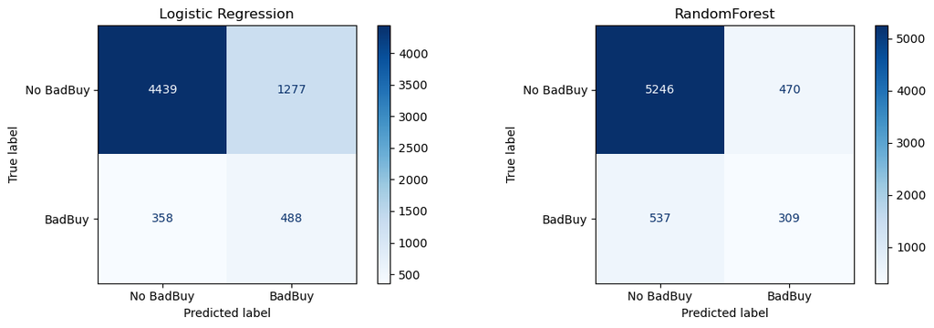

```python
# Logistic regression with optimized hyperparameters already yields comparatively good results with minimal
# computational effort

#===TrainData===
#precision:  0.26794167771255445
#recall:  0.5848718655276935
#f1:  0.3675165577247738
#===TestData===
#precision:  0.27648725212464587
#recall:  0.5768321513002365
#f1:  0.37380314055917274

# A recall score of 58% would be very beneficial for the company; in the future, 58% of mispurchases could be avoided

# The RF with BO, on the other hand, is a good way to improve precision — though the model suffers significantly from
# overfitting (the training data is predicted much better than the test data):

#===TrainData===
#precision:  0.6407416325547797
#recall:  0.7332598511986773
#f1:  0.6838858905165767

#===TestData===
#Precision:  0.39666238767650835
#Recall:  0.36524822695035464
#F1:  0.3803076923076923

# Visualizing confusion matrix for both models

from sklearn.metrics import confusion_matrix, ConfusionMatrixDisplay

fig, axes = plt.subplots(1, 2, figsize=(12, 4))

# Confusion Matrix LogReg
cm_log = confusion_matrix(target_test, result_log_test_grid)
disp1 = ConfusionMatrixDisplay(confusion_matrix=cm_log,
                                display_labels=['No BadBuy', 'BadBuy'])
disp1.plot(cmap='Blues', ax=axes[0])
axes[0].set_title('Logistic Regression')

# Confusion Matrix RF-BO
cm_rf = confusion_matrix(target_test, target_test_pred)
disp2 = ConfusionMatrixDisplay(confusion_matrix=cm_rf,
                                display_labels=['No BadBuy', 'BadBuy'])
disp2.plot(cmap='Blues', ax=axes[1])
axes[1].set_title('RandomForest')

plt.tight_layout()
plt.show()
```

This clearly shows once again that LogReg correctly identifies more “lemon cars” (488 vs. only 309 for RF), while it also classifies more cars as “lemon cars” that are actually in good condition (1277 vs. 470)

LogReg would therefore be suitable for a conservative company that wants to avoid costs RF would be suitable for a company that wants to maximize revenue and can afford more “lemon cars” (e.g., because it can still sell the individual parts or has large warehouses)

final decision for log reg model because it is simple, fast and sufficiently good for this project

## Final Data pipeline / function to predict “lemon cars” in aim data set

```python
def final_pipe (csv, model):
    '''Predicts Bad-Buy-Cars on Aim Dataset
    Arguments:
    csv (str): path to data file in csv format
    model (model): the trained model
    Returns: 1 = badbuy, 0 = not a badbuy
    '''
    #1. Read Data
    import pandas as pd
    df_aim = pd.read_csv(csv)

    #2. Load parameter
    params = joblib.load('all_params.joblib')

    #3. Run functions with loaded parameters
    df_aim, _ , _ , _  = clean_data(df_aim, params['median'], params['mode'], params['mad'], outlier_col='VehBCost')
    df_aim, _     = engineer_features(df_aim, params['top_categories'])

    #4. Define features for PCA and run PCA
    features_mmr = ['MMRAcquisitionAuctionAveragePrice','MMRAcquisitionAuctionCleanPrice',
                'MMRAcquisitionRetailAveragePrice',
                'MMRAcquisitonRetailCleanPrice', 'MMRCurrentAuctionAveragePrice',
                'MMRCurrentAuctionCleanPrice', 'MMRCurrentRetailAveragePrice',
                'MMRCurrentRetailCleanPrice']

    df_aim, _ , _     = pca_data(df_aim, params['pca_pipeline'])

    #5. Define features that need additional outlier trimming
    outlier_cols = ['Warr/Cost'] + pca_cols

    df_aim, _ , _  = trim_outliers_new(df_aim, outlier_cols, params['median_new'], params['mad_new'])

    #6. Define features for onehot encoding and standardization and transform those features
    cat_cols = ['Auction', 'Make', 'Color', 'WheelType', 'Nationality', 'Size', 'TopThreeAmericanName']
    num_cols = ['VehYear', 'VehicleAge', 'VehOdo', 'VehBCost', 'WarrantyCost', 'Warr/Cost', 'pca_0']

    df_aim, _     = transform_features(df_aim, cat_cols, num_cols, params['ct'])

    #7. Predict
    predictions = model.predict(df_aim)
    return predictions
```

```python
import joblib
model = joblib.load('best_model_log.pkl')
```

```python
#predict
y_pred = final_pipe('features_aim.csv', model)
pd.Series(y_pred).to_csv('predictions_aim.csv', index=False)
```

```python
print(y_pred.mean())
```

```
0.26741634668129455
```

## Model Interpretation - feature importance

What features are important for predicting “lemon cars” according to the final model? What makes a used car hardly resalable?

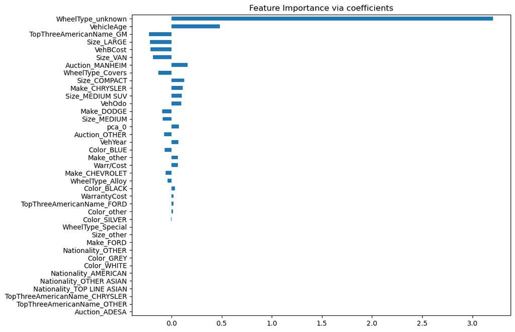

```python
import matplotlib.pyplot as plt

coefs = pd.Series(
    model.named_steps['classifier'].coef_[0],
    index=features_train.columns.tolist()
).sort_values(key=abs, ascending=True)

coefs.plot(kind='barh', figsize=(10, 8))
plt.title('Feature Importance via coefficients')
plt.show()
```

```python
#alternatively odd ratios can be calculated:
import numpy as np

odds_ratios = pd.Series(
    np.exp(model.named_steps['classifier'].coef_[0]),
    index=features_train.columns.tolist()
).sort_values(ascending=False)

print(odds_ratios)
```

```
WheelType_unknown                24.729708
VehicleAge                        1.620290
Auction_MANHEIM                   1.176939
Size_COMPACT                      1.134090
Make_CHRYSLER                     1.119514
Size_MEDIUM SUV                   1.106860
VehOdo                            1.103512
pca_0                             1.077101
VehYear                           1.069588
Make_other                        1.067477
Warr/Cost                         1.066797
Color_BLACK                       1.035228
WarrantyCost                      1.021575
TopThreeAmericanName_FORD         1.019207
Color_other                       1.013534
WheelType_Special                 1.000001
Size_other                        1.000001
Nationality_TOP LINE ASIAN        1.000000
TopThreeAmericanName_CHRYSLER     1.000000
TopThreeAmericanName_OTHER        1.000000
Auction_ADESA                     1.000000
Nationality_OTHER ASIAN           1.000000
Color_WHITE                       1.000000
Make_FORD                         1.000000
Color_GREY                        1.000000
Nationality_AMERICAN              1.000000
Nationality_OTHER                 1.000000
Color_SILVER                      0.996897
WheelType_Alloy                   0.961358
Make_CHEVROLET                    0.942567
Color_BLUE                        0.935341
Auction_OTHER                     0.930428
Size_MEDIUM                       0.914686
Make_DODGE                        0.913332
WheelType_Covers                  0.879258
Size_VAN                          0.830717
VehBCost                          0.810492
Size_LARGE                        0.809353
TopThreeAmericanName_GM           0.799398
dtype: float64
```

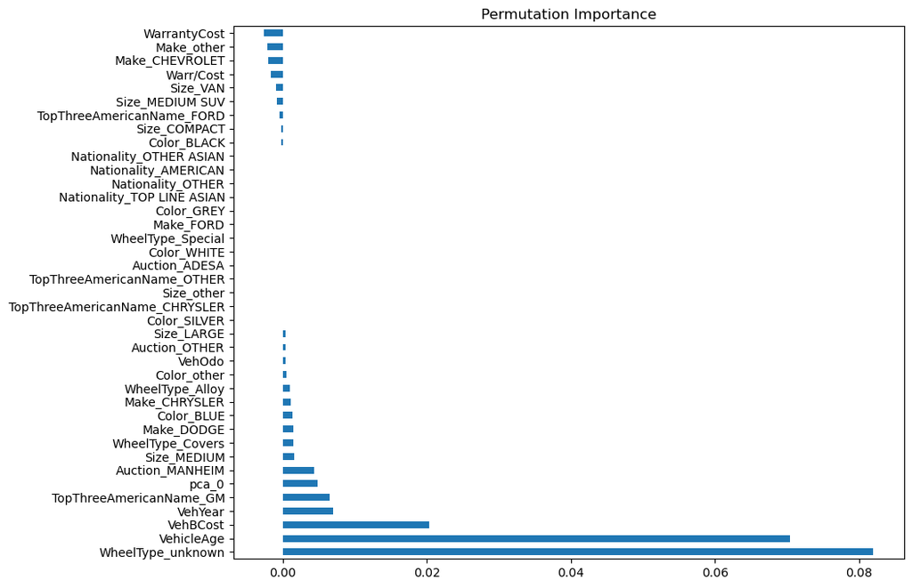

```python
#Permutation importance (Model agnostic)

from sklearn.inspection import permutation_importance

result = permutation_importance(model, features_test, target_test,
                                n_repeats=10,
                                scoring='f1',
                                random_state=42)

importance = pd.Series(
    result.importances_mean,
    index=features_test.columns.tolist()
).sort_values(ascending=False)

importance.plot(kind='barh', figsize=(10, 8))
plt.title('Permutation Importance')
plt.show()
```

- higher values (the difference in F1 scores between the “normal” and permuted models) indicate greater importance of the feature
- if the value is zero, the model does not change when the feature is randomly varied
- negative values indicate that the F1 score improves when the feature is permuted — in further model optimizations, such features should be removed
- here we see that the unknown wheel type remains the most important feature
- the age of the car was already important before, but is now almost as important for the prediction as the wheel type.
- purchase cost, year of manufacture, GM, pca_0, and MANHEIM are other important features
- according to this evaluation, features such as Warranty Costs and Chevrolet seem to hinder the prediction rather than help it

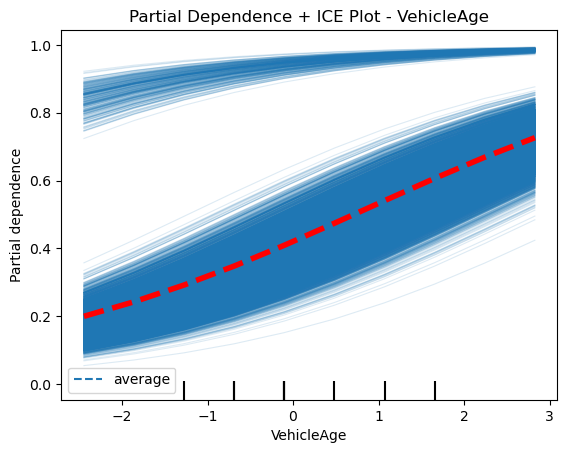

```python
# ICE Plot (Individual Conditional Expectation) for vehicle age (and partial dependence plot for comparing with average)

from sklearn.inspection import PartialDependenceDisplay
import matplotlib.pyplot as plt

feature = 'VehicleAge'

#fig, ax = plt.subplots(figsize=(8, 5))

PartialDependenceDisplay.from_estimator(
    model,
    features_train,
    ['VehicleAge'],
    kind='both',
    subsample=0.1,
    random_state=42
)

ax = plt.gca()

for line in ax.lines:
    label = line.get_label()

    if label != 'average':  # ICE Linien
        line.set_alpha(0.15)
        line.set_linewidth(0.8)
    else:  # PDP
        line.set_linewidth(4)
        line.set_color('red')
        line.set_zorder(10)

plt.title('Partial Dependence + ICE Plot - VehicleAge')
plt.show()
```

There are two bundles of used cars: the bigger lower bundle where the chance of becoming a lemon car increases with vehicle age and a smaller (in terms of n) bundle in the upper part of the plot where the chance of being a lemon car is already quite high and rises only slightly with vehicle age. These are probably the cars with unknown wheeltype which are hardly resalable (largely) regardless of their age.

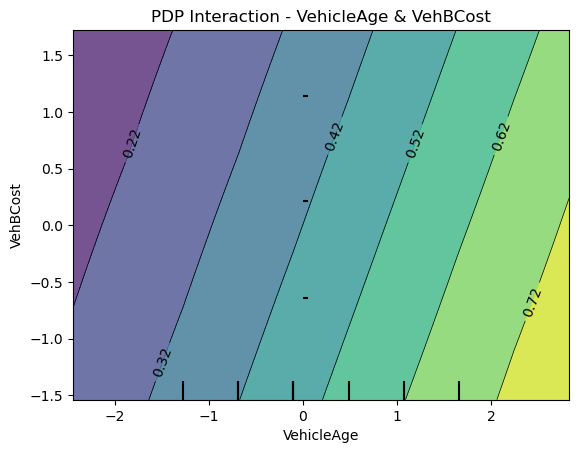

```python
PartialDependenceDisplay.from_estimator(
    model,
    features_train,
    [('VehicleAge', 'VehBCost')],
    kind='average',
    grid_resolution=50
)

plt.title('PDP Interaction - VehicleAge & VehBCost')
plt.show()
```

The purchase price for the vehicle at the time of purchase and the vehicle age show an additive interaction on the chance to be a lemon car: the cheaper the car and the older the car is the more likely it is a lemon car.

```python
import sys
!{sys.executable} -m pip install shap
```

[output not shown]

```python
print(sys.executable)
```

```
C:\ProgramData\anaconda3\python.exe
```

```
Background dataset has 6562 samples but max_samples=100. Subsampling to 100 samples for SHAP value computation. To use all samples, set max_samples=6562 when initializing the masker.
```

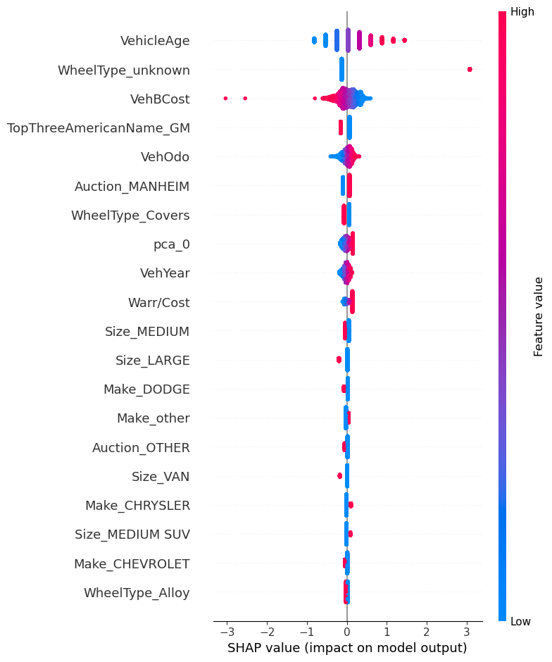

```python
# SHAP (SHapley Additive exPlanations) Contribution of each feature to the prediction – based on game theory (Shapley values)
import shap

explainer = shap.LinearExplainer(model.named_steps['classifier'],
                                  features_test, max_samples=1000)
shap_values = explainer.shap_values(features_test)

shap.summary_plot(shap_values, features_test,
                  feature_names=features_test.columns.tolist())
```